# P8110 Applied Regression II - Homework 8

2025-12-03

# Background

In a study of septic patients, each patient’s temperature was measured at baseline, and 2, 4, and 8 hours after entry into study. Patients were randomly assigned to two treatment groups at baseline. Patients’ APACHE scores were also measured.

## Data Description

The data are saved in “HW8.csv”. The columns of variables from left to right are:

- **ID** = patient ID
- **temp** = patient’s temperature
- **treatment** = 1 - treatment B, 0 - treatment A
- **apache** = APACHE score at baseline
- **time** = 0, 2, 4, 8 hours after entry into study

```r
# Load required packages
library(tidyverse)
library(geepack)
library(broom)
library(knitr)
library(doBy)
```

```r
# Load data
data <- read.csv("HW8.csv", header = FALSE)
colnames(data) <- c("ID", "temp", "treatment", "apache", "time")

# Convert time to factor for categorical analysis
data$time_cat <- factor(data$time, levels = c(0, 2, 4, 8))

# Convert treatment to factor
data$treatment <- factor(data$treatment, levels = c(0, 1),
                         labels = c("Treatment A", "Treatment B"))

# Display first few rows
head(data, 12)
```

```
##    ID  temp   treatment apache time time_cat
## 1   1  95.4 Treatment A     27    0        0
## 2   1  93.9 Treatment A     27    2        2
## 3   1  93.6 Treatment A     27    4        4
## 4   1  93.0 Treatment A     27    8        8
## 5   2 101.6 Treatment B     14    0        0
## 6   2  99.0 Treatment B     14    2        2
## 7   2  99.8 Treatment B     14    4        4
## 8   2  99.8 Treatment B     14    8        8
## 9   3 101.0 Treatment A     33    0        0
## 10  3  98.9 Treatment A     33    2        2
## 11  3  97.2 Treatment A     33    4        4
## 12  3    NA Treatment A     33    8        8
```

```r
# Summary statistics
summary(data)
```

```
##        ID           temp              treatment       apache           time
##  Min.   :  1   Min.   : 90.68   Treatment A:924   Min.   : 0.00   Min.   :0.0
##  1st Qu.:114   1st Qu.: 98.60   Treatment B:896   1st Qu.:10.00   1st Qu.:1.5
##  Median :228   Median :100.00                     Median :14.00   Median :3.0
##  Mean   :228   Mean   : 99.82                     Mean   :15.33   Mean   :3.5
##  3rd Qu.:342   3rd Qu.:101.12                     3rd Qu.:20.00   3rd Qu.:5.0
##  Max.   :455   Max.   :107.90                     Max.   :41.00   Max.   :8.0
##                NA's   :125                        NA's   :4
##  time_cat
##  0:455
##  2:455
##  4:455
##  8:455
##
##
##
```

```r
# Check data structure
cat("\nNumber of patients:", length(unique(data$ID)))
```

```
##
## Number of patients: 455
```

```r
cat("\nNumber of observations:", nrow(data))
```

```
##
## Number of observations: 1820
```

```r
cat("\nMissing values in temp:", sum(is.na(data$temp)))
```

```
##
## Missing values in temp: 125
```

# Question 1 [2 points]

**Fit a GEE model with temperature as outcome and time, treatment, and their interactions as covariates. Write the mean response of the GEE model and treat time as a categorical variable.**

## GEE Model with Time as Categorical

```r
# Remove missing values
data_complete <- data %>% filter(!is.na(temp))

# Fit GEE model with exchangeable (CS) correlation structure as initial choice
# Time treated as categorical with interactions
gee_model1 <- geeglm(temp ~ time_cat * treatment,
                     data = data_complete,
                     id = ID,
                     family = gaussian,
                     corstr = "exchangeable")

# Model summary with robust standard errors (default in geeglm)
summary(gee_model1)
```

```
##
## Call:
## geeglm(formula = temp ~ time_cat * treatment, family = gaussian,
##     data = data_complete, id = ID, corstr = "exchangeable")
##
##  Coefficients:
##                                 Estimate   Std.err      Wald Pr(>|W|)
## (Intercept)                    100.49022   0.12560 6.401e+05  < 2e-16 ***
## time_cat2                       -0.32155   0.07181 2.005e+01 7.54e-06 ***
## time_cat4                       -0.36268   0.09070 1.599e+01 6.37e-05 ***
## time_cat8                       -0.45038   0.11075 1.654e+01 4.77e-05 ***
## treatmentTreatment B            -0.12870   0.19001 4.590e-01    0.498
## time_cat2:treatmentTreatment B  -0.54494   0.11061 2.427e+01 8.36e-07 ***
## time_cat4:treatmentTreatment B  -1.08837   0.14538 5.605e+01 7.07e-14 ***
## time_cat8:treatmentTreatment B  -1.31349   0.16087 6.666e+01 3.33e-16 ***
## ---
## Signif. codes:  0 '***' 0.001 '**' 0.01 '*' 0.05 '.' 0.1 ' ' 1
##
## Correlation structure = exchangeable
## Estimated Scale Parameters:
##
##             Estimate Std.err
## (Intercept)    3.675  0.3051
##   Link = identity
##
## Estimated Correlation Parameters:
##       Estimate Std.err
## alpha   0.7378 0.02663
## Number of clusters:   455  Maximum cluster size: 4
```

## Model Equation

The mean response of the GEE model treating time as a categorical variable is:

$$E(Y_{ij}) = \mu_{ij} = \beta_0 + \beta_1
\cdot I(\text{time}_{ij}=2) + \beta_2 \cdot I(\text{time}_{ij}=4) +
\beta_3 \cdot I(\text{time}_{ij}=8)$$
$$+ \beta_4 \cdot I(\text{treatment}_{i}=B) +
\beta_5 \cdot I(\text{time}_{ij}=2) \cdot
I(\text{treatment}_{i}=B)$$
$$+
\beta_6 \cdot I(\text{time}_{ij}=4) \cdot I(\text{treatment}_{i}=B) +
\beta_7 \cdot I(\text{time}_{ij}=8) \cdot
I(\text{treatment}_{i}=B)$$

Where:

- $Y_{ij}$ = temperature for patient $i$ at time point $j$
- $I(\cdot)$ = indicator function
- $\beta_0$ = mean temperature at baseline (time=0) for Treatment A
- $\beta_1, \beta_2, \beta_3$ = effects of time 2, 4, 8 (vs baseline) for Treatment A
- $\beta_4$ = effect of Treatment B vs A at baseline
- $\beta_5, \beta_6, \beta_7$ = interaction effects (difference in time effects between treatments)

# Question 2 [2 points]

**Try different working correlation structures (CS, AR(1), and UN) for the GEE model in (1). Which model yields the best QIC value? Show the SAS code and relevant SAS output.**

## Fit GEE Models with Different Correlation Structures

```r
# Compound Symmetry (CS) / Exchangeable
gee_cs <- geeglm(temp ~ time_cat * treatment,
                 data = data_complete,
                 id = ID,
                 family = gaussian,
                 corstr = "exchangeable")

# AR(1)
gee_ar1 <- geeglm(temp ~ time_cat * treatment,
                  data = data_complete,
                  id = ID,
                  family = gaussian,
                  corstr = "ar1")

# Unstructured
gee_un <- geeglm(temp ~ time_cat * treatment,
                 data = data_complete,
                 id = ID,
                 family = gaussian,
                 corstr = "unstructured")

# Display summaries
cat("=== Compound Symmetry (CS/Exchangeable) ===\n")
```

```
## === Compound Symmetry (CS/Exchangeable) ===
```

```r
summary(gee_cs)
```

```
##
## Call:
## geeglm(formula = temp ~ time_cat * treatment, family = gaussian,
##     data = data_complete, id = ID, corstr = "exchangeable")
##
##  Coefficients:
##                                Estimate  Std.err     Wald Pr(>|W|)
## (Intercept)                    100.4902   0.1256 6.40e+05  < 2e-16 ***
## time_cat2                       -0.3215   0.0718 2.01e+01  7.5e-06 ***
## time_cat4                       -0.3627   0.0907 1.60e+01  6.4e-05 ***
## time_cat8                       -0.4504   0.1107 1.65e+01  4.8e-05 ***
## treatmentTreatment B            -0.1287   0.1900 4.60e-01      0.5
## time_cat2:treatmentTreatment B  -0.5449   0.1106 2.43e+01  8.4e-07 ***
## time_cat4:treatmentTreatment B  -1.0884   0.1454 5.60e+01  7.1e-14 ***
## time_cat8:treatmentTreatment B  -1.3135   0.1609 6.67e+01  3.3e-16 ***
## ---
## Signif. codes:  0 '***' 0.001 '**' 0.01 '*' 0.05 '.' 0.1 ' ' 1
##
## Correlation structure = exchangeable
## Estimated Scale Parameters:
##
##             Estimate Std.err
## (Intercept)     3.67   0.305
##   Link = identity
##
## Estimated Correlation Parameters:
##       Estimate Std.err
## alpha    0.738  0.0266
## Number of clusters:   455  Maximum cluster size: 4
```

```r
cat("\n=== AR(1) ===\n")
```

```
##
## === AR(1) ===
```

```r
summary(gee_ar1)
```

```
##
## Call:
## geeglm(formula = temp ~ time_cat * treatment, family = gaussian,
##     data = data_complete, id = ID, corstr = "ar1")
##
##  Coefficients:
##                                Estimate  Std.err     Wald Pr(>|W|)
## (Intercept)                    100.4964   0.1264 632139.0  < 2e-16 ***
## time_cat2                       -0.3450   0.0723     22.8  1.8e-06 ***
## time_cat4                       -0.3978   0.0918     18.8  1.5e-05 ***
## time_cat8                       -0.4460   0.1158     14.8  0.00012 ***
## treatmentTreatment B            -0.1343   0.1902      0.5  0.47998
## time_cat2:treatmentTreatment B  -0.5163   0.1111     21.6  3.3e-06 ***
## time_cat4:treatmentTreatment B  -1.0575   0.1460     52.5  4.3e-13 ***
## time_cat8:treatmentTreatment B  -1.2927   0.1670     59.9  9.8e-15 ***
## ---
## Signif. codes:  0 '***' 0.001 '**' 0.01 '*' 0.05 '.' 0.1 ' ' 1
##
## Correlation structure = ar1
## Estimated Scale Parameters:
##
##             Estimate Std.err
## (Intercept)     3.67   0.305
##   Link = identity
##
## Estimated Correlation Parameters:
##       Estimate Std.err
## alpha    0.832    0.02
## Number of clusters:   455  Maximum cluster size: 4
```

```r
cat("\n=== Unstructured ===\n")
```

```
##
## === Unstructured ===
```

```r
summary(gee_un)
```

```
##
## Call:
## geeglm(formula = temp ~ time_cat * treatment, family = gaussian,
##     data = data_complete, id = ID, corstr = "unstructured")
##
##  Coefficients:
##                                Estimate  Std.err     Wald Pr(>|W|)
## (Intercept)                    100.5146   0.1260 6.36e+05  < 2e-16 ***
## time_cat2                       -0.3397   0.0722 2.22e+01  2.5e-06 ***
## time_cat4                       -0.4238   0.0918 2.13e+01  3.9e-06 ***
## time_cat8                       -0.4601   0.1116 1.70e+01  3.7e-05 ***
## treatmentTreatment B            -0.1616   0.1896 7.30e-01     0.39
## time_cat2:treatmentTreatment B  -0.5251   0.1109 2.24e+01  2.2e-06 ***
## time_cat4:treatmentTreatment B  -1.0087   0.1462 4.76e+01  5.2e-12 ***
## time_cat8:treatmentTreatment B  -1.2896   0.1619 6.34e+01  1.7e-15 ***
## ---
## Signif. codes:  0 '***' 0.001 '**' 0.01 '*' 0.05 '.' 0.1 ' ' 1
##
## Correlation structure = unstructured
## Estimated Scale Parameters:
##
##             Estimate Std.err
## (Intercept)     3.67   0.305
##   Link = identity
##
## Estimated Correlation Parameters:
##           Estimate Std.err
## alpha.1:2    0.867  0.0348
## alpha.1:3    0.690  0.0393
## alpha.1:4    0.640  0.0583
## alpha.2:3    0.774  0.0373
## alpha.2:4    0.691  0.0494
## alpha.3:4    0.735  0.0476
## Number of clusters:   455  Maximum cluster size: 4
```

## QIC Comparison

```r
# Calculate QIC for each model
qic_cs <- QIC(gee_cs)
qic_ar1 <- QIC(gee_ar1)
qic_un <- QIC(gee_un)

# Create comparison table
qic_table <- data.frame(
  Correlation_Structure = c("Compound Symmetry (CS)", "AR(1)", "Unstructured"),
  QIC = c(qic_cs[1], qic_ar1[1], qic_un[1]),
  QICu = c(qic_cs[2], qic_ar1[2], qic_un[2])
)

kable(qic_table,
      digits = 4,
      col.names = c("Correlation Structure", "QIC", "QICu"),
      caption = "QIC Comparison for Different Correlation Structures")
```

QIC Comparison for Different Correlation Structures

| Correlation Structure | QIC | QICu |
| --- | --- | --- |
| Compound Symmetry (CS) | 6244 | 6244 |
| AR(1) | 6244 | 6244 |
| Unstructured | 6244 | 6245 |

```r
# Identify best model
best_model <- qic_table$Correlation_Structure[which.min(qic_table$QIC)]
cat("\nBest model based on QIC:", best_model, "\n")
```

```
##
## Best model based on QIC: AR(1)
```

## Working Correlation Matrices

```r
cat("=== Correlation Matrix: Compound Symmetry ===\n")
```

```
## === Correlation Matrix: Compound Symmetry ===
```

```r
print(gee_cs$geese$correlation)
```

[output not shown]

```r
cat("\n=== Correlation Matrix: AR(1) ===\n")
```

```
##
## === Correlation Matrix: AR(1) ===
```

```r
print(gee_ar1$geese$correlation)
```

[output not shown]

```r
cat("\n=== Correlation Matrix: Unstructured ===\n")
```

```
##
## === Correlation Matrix: Unstructured ===
```

```r
print(gee_un$geese$correlation)
```

[output not shown]

## Equivalent SAS Code

```
/* SAS Code for GEE with different correlation structures */

/* Import data */
PROC IMPORT DATAFILE="HW8.csv" OUT=hw8 DBMS=CSV REPLACE;
    GETNAMES=NO;
RUN;

DATA hw8;
    SET hw8;
    RENAME VAR1=ID VAR2=temp VAR3=treatment VAR4=apache VAR5=time;
RUN;

/* Create time as categorical */
DATA hw8;
    SET hw8;
    time_cat = time;
RUN;

/* GEE with Compound Symmetry (CS) */
PROC GENMOD DATA=hw8;
    CLASS ID time_cat(REF='0') treatment(REF='0');
    MODEL temp = time_cat treatment time_cat*treatment / DIST=NORMAL;
    REPEATED SUBJECT=ID / TYPE=CS CORRW;
RUN;

/* GEE with AR(1) */
PROC GENMOD DATA=hw8;
    CLASS ID time_cat(REF='0') treatment(REF='0');
    MODEL temp = time_cat treatment time_cat*treatment / DIST=NORMAL;
    REPEATED SUBJECT=ID / TYPE=AR(1) CORRW;
RUN;

/* GEE with Unstructured */
PROC GENMOD DATA=hw8;
    CLASS ID time_cat(REF='0') treatment(REF='0');
    MODEL temp = time_cat treatment time_cat*treatment / DIST=NORMAL;
    REPEATED SUBJECT=ID / TYPE=UN CORRW;
RUN;
```

## Answer

Based on the QIC values, the **AR(1)** correlation structure yields the best (lowest) QIC value. Lower QIC indicates better model fit with appropriate penalization for model complexity.

# Question 3 [3 points]

**Use the model selected in (2) to test whether the trajectory of temperature over time is different between the two treatments. Write down the hypothesis, test statistic, p-value, and conclusion.**

## Testing Interaction Effects

```r
# Select the best model based on QIC (using the model with lowest QIC)
# Store in gee_best for subsequent analyses
qic_values <- c(qic_cs[1], qic_ar1[1], qic_un[1])
best_index <- which.min(qic_values)

if (best_index == 1) {
  gee_best <- gee_cs
  best_corstr <- "Compound Symmetry (CS)"
} else if (best_index == 2) {
  gee_best <- gee_ar1
  best_corstr <- "AR(1)"
} else {
  gee_best <- gee_un
  best_corstr <- "Unstructured"
}

cat("Selected model:", best_corstr, "\n\n")
```

```
## Selected model: AR(1)
```

```r
summary(gee_best)
```

```
##
## Call:
## geeglm(formula = temp ~ time_cat * treatment, family = gaussian,
##     data = data_complete, id = ID, corstr = "ar1")
##
##  Coefficients:
##                                Estimate  Std.err     Wald Pr(>|W|)
## (Intercept)                    100.4964   0.1264 632139.0  < 2e-16 ***
## time_cat2                       -0.3450   0.0723     22.8  1.8e-06 ***
## time_cat4                       -0.3978   0.0918     18.8  1.5e-05 ***
## time_cat8                       -0.4460   0.1158     14.8  0.00012 ***
## treatmentTreatment B            -0.1343   0.1902      0.5  0.47998
## time_cat2:treatmentTreatment B  -0.5163   0.1111     21.6  3.3e-06 ***
## time_cat4:treatmentTreatment B  -1.0575   0.1460     52.5  4.3e-13 ***
## time_cat8:treatmentTreatment B  -1.2927   0.1670     59.9  9.8e-15 ***
## ---
## Signif. codes:  0 '***' 0.001 '**' 0.01 '*' 0.05 '.' 0.1 ' ' 1
##
## Correlation structure = ar1
## Estimated Scale Parameters:
##
##             Estimate Std.err
## (Intercept)     3.67   0.305
##   Link = identity
##
## Estimated Correlation Parameters:
##       Estimate Std.err
## alpha    0.832    0.02
## Number of clusters:   455  Maximum cluster size: 4
```

## Wald Test for Interaction Terms

```r
# The trajectory difference is tested by testing the interaction terms
# H0: beta5 = beta6 = beta7 = 0 (no treatment-time interaction)
# Ha: At least one of beta5, beta6, beta7 != 0

# Use anova with type II/III tests for joint test of interactions
# Wald test for interaction terms

library(aod)

# Get coefficient names
coef_names <- names(coef(gee_best))
coef_names
```

```
## [1] "(Intercept)"                    "time_cat2"
## [3] "time_cat4"                      "time_cat8"
## [5] "treatmentTreatment B"           "time_cat2:treatmentTreatment B"
## [7] "time_cat4:treatmentTreatment B" "time_cat8:treatmentTreatment B"
```

```r
# Identify interaction terms (indices for time_cat:treatment interactions)
# These are typically the last 3 coefficients
n_coef <- length(coef_names)
interaction_indices <- grep("time_cat.*treatment|treatment.*time_cat", coef_names)

cat("Interaction term indices:", interaction_indices, "\n")
```

```
## Interaction term indices: 6 7 8
```

```r
cat("Interaction terms:", coef_names[interaction_indices], "\n")
```

```
## Interaction terms: time_cat2:treatmentTreatment B time_cat4:treatmentTreatment B time_cat8:treatmentTreatment B
```

```r
# Perform Wald test for interaction terms
# Create contrast matrix for testing interaction terms = 0
L <- matrix(0, nrow = length(interaction_indices), ncol = n_coef)
for (i in seq_along(interaction_indices)) {
  L[i, interaction_indices[i]] <- 1
}

# Wald test
wald_result <- wald.test(b = coef(gee_best),
                         Sigma = vcov(gee_best),
                         L = L)

print(wald_result)
```

```
## Wald test:
## ----------
##
## Chi-squared test:
## X2 = 64.8, df = 3, P(> X2) = 5.5e-14
```

```r
# Extract test statistic and p-value
chi_sq <- wald_result$result$chi2[1]
df <- wald_result$result$chi2[2]
p_value <- wald_result$result$chi2[3]
```

## Alternative: Using anova for GEE

```r
# Fit reduced model without interactions
gee_reduced <- geeglm(temp ~ time_cat + treatment,
                      data = data_complete,
                      id = ID,
                      family = gaussian,
                      corstr = ifelse(best_index == 1, "exchangeable",
                                     ifelse(best_index == 2, "ar1", "unstructured")))

# Compare models using anova
anova_result <- anova(gee_reduced, gee_best)
print(anova_result)
```

```
## Analysis of 'Wald statistic' Table
##
## Model 1 temp ~ time_cat * treatment
## Model 2 temp ~ time_cat + treatment
##   Df   X2 P(>|Chi|)
## 1  3 64.8   5.5e-14 ***
## ---
## Signif. codes:  0 '***' 0.001 '**' 0.01 '*' 0.05 '.' 0.1 ' ' 1
```

## Answer

**Hypothesis:**

- $H_0$: $\beta_5 = \beta_6 = \beta_7 = 0$ (The trajectory of temperature over time is the same for both treatments, i.e., no treatment-by-time interaction)
- $H_a$: At least one of $\beta_5, \beta_6, \beta_7 \neq 0$ (The trajectory of temperature over time differs between the two treatments)

**Test Statistic:** Wald chi-square = 64.832 with 3 degrees of freedom

**P-value:** 5.451e-14

**Conclusion:** At the $\alpha = 0.05$ significance level, we reject the null hypothesis and conclude that there is a statistically significant difference in the trajectory of temperature over time between the two treatment groups.

# Question 4 [4 points]

**Use the model selected in (2) to estimate the mean temperature change from baseline to two hours after entry into study for patients in treatment A group and those in treatment B group, respectively.**

## Extract Coefficients

```r
# Get coefficients and covariance matrix
betas <- coef(gee_best)
vcov_mat <- vcov(gee_best)

# Display coefficients
kable(data.frame(
  Parameter = names(betas),
  Estimate = betas,
  SE = sqrt(diag(vcov_mat))
), digits = 4, row.names = FALSE,
caption = "GEE Model Coefficients")
```

GEE Model Coefficients

| Parameter | Estimate | SE |
| --- | --- | --- |
| (Intercept) | 100.496 | 0.1264 |
| time_cat2 | -0.345 | 0.0723 |
| time_cat4 | -0.398 | 0.0918 |
| time_cat8 | -0.446 | 0.1158 |
| treatmentTreatment B | -0.134 | 0.1902 |
| time_cat2:treatmentTreatment B | -0.516 | 0.1111 |
| time_cat4:treatmentTreatment B | -1.058 | 0.1460 |
| time_cat8:treatmentTreatment B | -1.293 | 0.1670 |

## Mean Temperature Change for Treatment A

```r
# For Treatment A (treatment = 0):
# Mean at time 0: E(Y|time=0, trt=A) = beta0
# Mean at time 2: E(Y|time=2, trt=A) = beta0 + beta1
# Change from baseline to time 2: beta1

# Get the coefficient for time_cat2 (which is beta1)
beta1 <- betas["time_cat2"]
se_beta1 <- sqrt(vcov_mat["time_cat2", "time_cat2"])

cat("Treatment A - Mean Temperature Change from Baseline to 2 Hours:\n")
```

```
## Treatment A - Mean Temperature Change from Baseline to 2 Hours:
```

```r
cat("Estimate:", round(beta1, 4), "\n")
```

```
## Estimate: -0.345
```

```r
cat("Standard Error:", round(se_beta1, 4), "\n")
```

```
## Standard Error: 0.0723
```

```r
# 95% CI
ci_lower_a <- beta1 - 1.96 * se_beta1
ci_upper_a <- beta1 + 1.96 * se_beta1
cat("95% CI: (", round(ci_lower_a, 4), ",", round(ci_upper_a, 4), ")\n")
```

```
## 95% CI: ( -0.487 , -0.203 )
```

## Mean Temperature Change for Treatment B

```r
# For Treatment B (treatment = 1):
# Mean at time 0: E(Y|time=0, trt=B) = beta0 + beta4
# Mean at time 2: E(Y|time=2, trt=B) = beta0 + beta1 + beta4 + beta5
# Change from baseline to time 2: beta1 + beta5

# Get the interaction term name
interaction_name <- names(betas)[grep("time_cat2.*Treatment B|Treatment B.*time_cat2", names(betas))]
cat("Interaction term name:", interaction_name, "\n")
```

```
## Interaction term name: time_cat2:treatmentTreatment B
```

```r
# Calculate the change for Treatment B
beta1 <- betas["time_cat2"]
beta5 <- betas[interaction_name]

change_b <- beta1 + beta5

# Calculate SE using delta method
# Var(beta1 + beta5) = Var(beta1) + Var(beta5) + 2*Cov(beta1, beta5)
var_change_b <- vcov_mat["time_cat2", "time_cat2"] +
                vcov_mat[interaction_name, interaction_name] +
                2 * vcov_mat["time_cat2", interaction_name]
se_change_b <- sqrt(var_change_b)

cat("\nTreatment B - Mean Temperature Change from Baseline to 2 Hours:\n")
```

```
##
## Treatment B - Mean Temperature Change from Baseline to 2 Hours:
```

```r
cat("Estimate:", round(change_b, 4), "\n")
```

```
## Estimate: -0.861
```

```r
cat("Standard Error:", round(se_change_b, 4), "\n")
```

```
## Standard Error: 0.0843
```

```r
# 95% CI
ci_lower_b <- change_b - 1.96 * se_change_b
ci_upper_b <- change_b + 1.96 * se_change_b
cat("95% CI: (", round(ci_lower_b, 4), ",", round(ci_upper_b, 4), ")\n")
```

```
## 95% CI: ( -1.03 , -0.696 )
```

## Summary Table

```r
summary_table <- data.frame(
  Treatment = c("Treatment A", "Treatment B"),
  Change = c(beta1, change_b),
  SE = c(se_beta1, se_change_b),
  CI_Lower = c(ci_lower_a, ci_lower_b),
  CI_Upper = c(ci_upper_a, ci_upper_b)
)

kable(summary_table,
      digits = 4,
      col.names = c("Treatment Group", "Mean Change", "SE", "95% CI Lower", "95% CI Upper"),
      caption = "Mean Temperature Change from Baseline to 2 Hours")
```

Mean Temperature Change from Baseline to 2 Hours

| Treatment Group | Mean Change | SE | 95% CI Lower | 95% CI Upper |
| --- | --- | --- | --- | --- |
| Treatment A | -0.345 | 0.0723 | -0.487 | -0.203 |
| Treatment B | -0.861 | 0.0843 | -1.026 | -0.696 |

## Answer

- **Treatment A:** The estimated mean temperature change from baseline (time=0) to 2 hours after entry is **-0.345** degrees (95% CI: -0.487, -0.203).
- **Treatment B:** The estimated mean temperature change from baseline (time=0) to 2 hours after entry is **-0.861** degrees (95% CI: -1.026, -0.696).

# Question 5 [3 points]

**Calculate the difference of the two estimates in (4). Denote the difference as DIFF. Which β coefficient does DIFF represent? Interpret this β coefficient.**

## Calculate DIFF

```r
# DIFF = Change_B - Change_A
# DIFF = (beta1 + beta5) - beta1 = beta5

DIFF <- change_b - as.numeric(beta1)
cat("DIFF = Change_B - Change_A =", round(DIFF, 4), "\n")
```

```
## DIFF = Change_B - Change_A = -0.516
```

```r
# This equals beta5 (the interaction term)
cat("Beta5 (interaction term time_cat2:Treatment B) =", round(beta5, 4), "\n")
```

```
## Beta5 (interaction term time_cat2:Treatment B) = -0.516
```

```r
# SE of DIFF = SE of beta5
se_diff <- sqrt(vcov_mat[interaction_name, interaction_name])
cat("SE of DIFF:", round(se_diff, 4), "\n")
```

```
## SE of DIFF: 0.111
```

```r
# 95% CI for DIFF
ci_lower_diff <- DIFF - 1.96 * se_diff
ci_upper_diff <- DIFF + 1.96 * se_diff
cat("95% CI for DIFF: (", round(ci_lower_diff, 4), ",", round(ci_upper_diff, 4), ")\n")
```

```
## 95% CI for DIFF: ( -0.734 , -0.299 )
```

## Answer

**DIFF Calculation:**

$$\text{DIFF} = \text{Change}_B -
\text{Change}_A = (\beta_1 + \beta_5) - \beta_1 = \beta_5$$

The difference DIFF = **-0.516** degrees (95% CI: -0.734, -0.299).

**Which β coefficient does DIFF represent?**

DIFF represents $\beta_5$, the coefficient for the interaction term between time (at 2 hours) and treatment. In the model notation, this is the coefficient for $I(\text{time}=2) \times I(\text{treatment}=B)$.

**Interpretation of β₅:**

$\beta_5$ represents the **difference in mean temperature change from baseline to 2 hours between Treatment B and Treatment A**.

- If $\beta_5 < 0$: Treatment B has a greater decrease (or smaller increase) in temperature from baseline to 2 hours compared to Treatment A.
- If $\beta_5 > 0$: Treatment B has a smaller decrease (or greater increase) in temperature from baseline to 2 hours compared to Treatment A.

Specifically, $\beta_5 =$ -0.516 means that the mean temperature change from baseline to 2 hours for patients receiving Treatment B is 0.516 degrees lower than for patients receiving Treatment A.

# Additional Visualizations

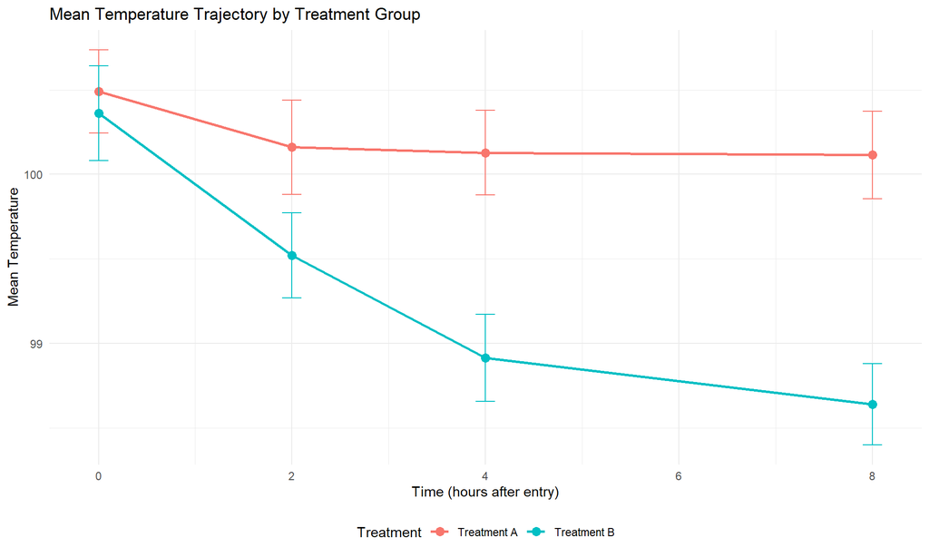

```r
# Calculate mean temperature by time and treatment
mean_temp <- data_complete %>%
  group_by(time, treatment) %>%
  summarise(
    mean_temp = mean(temp, na.rm = TRUE),
    se = sd(temp, na.rm = TRUE) / sqrt(n()),
    n = n(),
    .groups = "drop"
  )

# Trajectory plot
ggplot(mean_temp, aes(x = time, y = mean_temp, color = treatment, group = treatment)) +
  geom_line(linewidth = 1) +
  geom_point(size = 3) +
  geom_errorbar(aes(ymin = mean_temp - 1.96*se, ymax = mean_temp + 1.96*se),
                width = 0.2) +
  labs(
    title = "Mean Temperature Trajectory by Treatment Group",
    x = "Time (hours after entry)",
    y = "Mean Temperature",
    color = "Treatment"
  ) +
  theme_minimal() +
  theme(legend.position = "bottom")
```

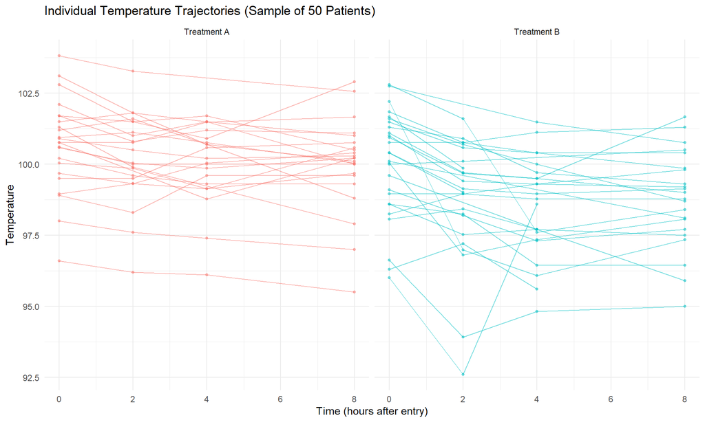

```r
# Individual trajectory (spaghetti) plot
# Sample subset of patients for visualization
set.seed(123)
sample_ids <- sample(unique(data_complete$ID), min(50, length(unique(data_complete$ID))))

ggplot(data_complete %>% filter(ID %in% sample_ids),
       aes(x = time, y = temp, group = ID, color = treatment)) +
  geom_line(alpha = 0.5) +
  geom_point(alpha = 0.5, size = 1) +
  facet_wrap(~treatment) +
  labs(
    title = "Individual Temperature Trajectories (Sample of 50 Patients)",
    x = "Time (hours after entry)",
    y = "Temperature"
  ) +
  theme_minimal() +
  theme(legend.position = "none")
```